# Biostat 203B Homework 5

Due Mar 22 @ 11:59PM

Author

Jiyin (Jenny) Zhang, UID: 606331859

## Predicting ICU duration

Using the ICU cohort `mimiciv_icu_cohort.rds` you built in Homework 4, develop at least three machine learning approaches (logistic regression with enet regularization, random forest, boosting, SVM, MLP, etc) plus a model stacking approach for predicting whether a patient’s ICU stay will be longer than 2 days. You should use the `los_long` variable as the outcome. You algorithms can use patient demographic information (gender, age at ICU `intime`, marital status, race), ICU admission information (first care unit), the last lab measurements before the ICU stay, and first vital measurements during ICU stay as features. You are welcome to use any feature engineering techniques you think are appropriate; but make sure to not use features that are not available at an ICU stay’s `intime`. For instance, `last_careunit` cannot be used in your algorithms.

# 0. Load necessary libraries.

```r
rm(list = ls())
library(dplyr) # for use of arrange()
library(tidymodels) # for use of initial_split()
library(gtsummary) # for use of tbl_summary()
library(xgboost)
library(stacks)
library(vip)
```

# 1. Data preprocessing and feature engineering.

Read in the dataset.

```r
mimiciv_icu_cohort <- readRDS("~/203b-hw/hw5/mimic_icu_cohort.rds")
```

Have a look at the dataset.

```r
mimiciv_icu_cohort %>% head()
```

```
# A tibble: 6 × 42
  subject_id  hadm_id  stay_id first_careunit  last_careunit intime
       <int>    <int>    <int> <fct>           <fct>         <dttm>
1   10106244 26713233 34344296 Other           Other         2147-05-09 10:35:46
2   15443666 27961368 39190279 Cardiac Vascul… Cardiac Vasc… 2168-12-31 00:19:16
3   15868868 27142491 30580878 Medical Intens… Medical Inte… 2191-08-07 15:29:06
4   10433099 28593361 31272962 Surgical Inten… Surgical Int… 2148-12-27 11:04:22
5   12862321 27343985 32737479 Medical Intens… Medical Inte… 2190-09-26 15:37:51
6   13730554 28211964 35400714 Medical/Surgic… Medical/Surg… 2157-11-24 22:10:57
# ℹ 36 more variables: outtime <dttm>, los <dbl>, admittime <dttm>,
#   dischtime <dttm>, deathtime <dttm>, admission_type <fct>,
#   admit_provider_id <chr>, admission_location <fct>,
#   discharge_location <fct>, insurance <chr>, language <chr>,
#   marital_status <chr>, race <chr>, edregtime <dttm>, edouttime <dttm>,
#   hospital_expire_flag <int>, gender <chr>, anchor_age <int>,
#   anchor_year <int>, anchor_year_group <chr>, dod <date>, …
```

# 2. Partition data into 50% training set and 50% test set. Stratify partitioning according to `los_long`. For grading purpose, sort the data by `subject_id`, `hadm_id`, and `stay_id` and use the seed `203` for the initial data split. Below is the sample code.

Sort the dataset.

```r
# sort
mimiciv_icu_cohort <- mimiciv_icu_cohort |>
  arrange(subject_id, hadm_id, stay_id) |>
  select(los_long, gender, age_intime,
         marital_status, race, first_careunit, bicarbonate, chloride,
         creatinine, glucose, potassium, sodium, hematocrit, wbc, heart_rate,
         non_invasive_blood_pressure_systolic, temperature_fahrenheit,
         non_invasive_blood_pressure_diastolic, respiratory_rate)
```

Find missing values in all the variables.

```r
# missing values
cat("Missing values in the dataset:\n")
```

```
Missing values in the dataset:
```

```r
print(colSums(is.na(mimiciv_icu_cohort)))
```

```
                             los_long                                gender
                                    0                                     0
                           age_intime                        marital_status
                                    0                                  5113
                                 race                        first_careunit
                                    0                                     0
                          bicarbonate                              chloride
                                 9050                                  8883
                           creatinine                               glucose
                                 5770                                  9099
                            potassium                                sodium
                                 8901                                  8872
                           hematocrit                                   wbc
                                 5017                                  5094
                           heart_rate  non_invasive_blood_pressure_systolic
                                   18                                   979
               temperature_fahrenheit non_invasive_blood_pressure_diastolic
                                 1361                                   983
                     respiratory_rate
                                   98
```

Check the type of variables in the dataset.

```r
dataset <- mimiciv_icu_cohort

# Loop through each column of the dataset
for (col_name in names(dataset)) {
  # Check if the column is numeric
  is_numeric <- is.numeric(dataset[[col_name]])
  # Check if the column is categorical (a factor)
  is_categorical <- is.factor(dataset[[col_name]])

  # Print information about the column
  cat("Variable:", col_name, "\n")
  if (is_numeric) {
    cat("   Data Type: Numeric\n")
  } else if (is_categorical) {
    cat("   Data Type: Categorical\n")
  } else {
    cat("   Data Type: Other\n")
  }
}
```

```
Variable: los_long
   Data Type: Other
Variable: gender
   Data Type: Other
Variable: age_intime
   Data Type: Numeric
Variable: marital_status
   Data Type: Other
Variable: race
   Data Type: Other
Variable: first_careunit
   Data Type: Categorical
Variable: bicarbonate
   Data Type: Numeric
Variable: chloride
   Data Type: Numeric
Variable: creatinine
   Data Type: Numeric
Variable: glucose
   Data Type: Numeric
Variable: potassium
   Data Type: Numeric
Variable: sodium
   Data Type: Numeric
Variable: hematocrit
   Data Type: Numeric
Variable: wbc
   Data Type: Numeric
Variable: heart_rate
   Data Type: Numeric
Variable: non_invasive_blood_pressure_systolic
   Data Type: Numeric
Variable: temperature_fahrenheit
   Data Type: Numeric
Variable: non_invasive_blood_pressure_diastolic
   Data Type: Numeric
Variable: respiratory_rate
   Data Type: Numeric
```

Change the variables into suitable types.

```r
# Change the variables into suitable types
mimiciv_icu_cohort <- mimiciv_icu_cohort |>
  mutate(los_long = as.factor(if_else(los_long, "yes", "no")),
         gender = as.factor(gender),
         marital_status = as.factor(marital_status),
         race = as.factor(race)
  )
```

Check the type of variables in the dataset again.

```r
dataset <- mimiciv_icu_cohort

# Loop through each column of the dataset
for (col_name in names(dataset)) {
  # Check if the column is numeric
  is_numeric <- is.numeric(dataset[[col_name]])
  # Check if the column is categorical (a factor)
  is_categorical <- is.factor(dataset[[col_name]])

  # Print information about the column
  cat("Variable:", col_name, "\n")
  if (is_numeric) {
    cat("   Data Type: Numeric\n")
  } else if (is_categorical) {
    cat("   Data Type: Categorical\n")
  } else {
    cat("   Data Type: Other\n")
  }
}
```

```
Variable: los_long
   Data Type: Categorical
Variable: gender
   Data Type: Categorical
Variable: age_intime
   Data Type: Numeric
Variable: marital_status
   Data Type: Categorical
Variable: race
   Data Type: Categorical
Variable: first_careunit
   Data Type: Categorical
Variable: bicarbonate
   Data Type: Numeric
Variable: chloride
   Data Type: Numeric
Variable: creatinine
   Data Type: Numeric
Variable: glucose
   Data Type: Numeric
Variable: potassium
   Data Type: Numeric
Variable: sodium
   Data Type: Numeric
Variable: hematocrit
   Data Type: Numeric
Variable: wbc
   Data Type: Numeric
Variable: heart_rate
   Data Type: Numeric
Variable: non_invasive_blood_pressure_systolic
   Data Type: Numeric
Variable: temperature_fahrenheit
   Data Type: Numeric
Variable: non_invasive_blood_pressure_diastolic
   Data Type: Numeric
Variable: respiratory_rate
   Data Type: Numeric
```

Numerical summaries stratified by the outcome `los_long`.

```r
mimiciv_icu_cohort |> tbl_summary(by = los_long)
```

| **Characteristic** | **no**, N = 38,050<sup>1</sup> | **yes**, N = 35,131<sup>1</sup> |
| --- | --- | --- |
| gender |  |  |
| F | 17,014 (45%) | 15,349 (44%) |
| M | 21,036 (55%) | 19,782 (56%) |
| age_intime | 65 (53, 77) | 67 (56, 78) |
| marital_status |  |  |
| DIVORCED | 2,843 (8.0%) | 2,561 (7.9%) |
| MARRIED | 16,984 (48%) | 15,784 (49%) |
| SINGLE | 11,175 (31%) | 9,683 (30%) |
| WIDOWED | 4,699 (13%) | 4,339 (13%) |
| Unknown | 2,349 | 2,764 |
| race |  |  |
| ASIAN | 1,148 (3.0%) | 1,007 (2.9%) |
| BLACK | 4,311 (11%) | 3,649 (10%) |
| HISPANIC | 1,492 (3.9%) | 1,249 (3.6%) |
| OTHER | 5,160 (14%) | 5,596 (16%) |
| WHITE | 25,939 (68%) | 23,630 (67%) |
| first_careunit |  |  |
| Cardiac Vascular Intensive Care Unit (CVICU) | 5,827 (15%) | 5,755 (16%) |
| Medical Intensive Care Unit (MICU) | 8,782 (23%) | 7,116 (20%) |
| Medical/Surgical Intensive Care Unit (MICU/SICU) | 7,147 (19%) | 5,586 (16%) |
| Surgical Intensive Care Unit (SICU) | 5,654 (15%) | 5,507 (16%) |
| Other | 10,640 (28%) | 11,167 (32%) |
| bicarbonate | 25.0 (22.0, 27.0) | 24.0 (21.0, 27.0) |
| Unknown | 4,270 | 4,780 |
| chloride | 102 (98, 105) | 102 (98, 105) |
| Unknown | 4,175 | 4,708 |
| creatinine | 1.00 (0.80, 1.40) | 1.00 (0.80, 1.60) |
| Unknown | 2,599 | 3,171 |
| glucose | 118 (98, 153) | 122 (100, 159) |
| Unknown | 4,282 | 4,817 |
| potassium | 4.20 (3.80, 4.60) | 4.20 (3.80, 4.70) |
| Unknown | 4,189 | 4,712 |
| sodium | 139.0 (136.0, 141.0) | 138.0 (135.0, 141.0) |
| Unknown | 4,174 | 4,698 |
| hematocrit | 36 (30, 40) | 35 (29, 40) |
| Unknown | 2,236 | 2,781 |
| wbc | 9.0 (6.6, 12.6) | 9.7 (7.0, 13.8) |
| Unknown | 2,272 | 2,822 |
| heart_rate | 85 (74, 99) | 88 (76, 103) |
| Unknown | 17 | 1 |
| non_invasive_blood_pressure_systolic | 122 (107, 139) | 120 (104, 138) |
| Unknown | 732 | 247 |
| temperature_fahrenheit | 98.10 (97.60, 98.60) | 98.20 (97.60, 98.80) |
| Unknown | 1,188 | 173 |
| non_invasive_blood_pressure_diastolic | 68 (58, 80) | 66 (55, 79) |
| Unknown | 733 | 250 |
| respiratory_rate | 18.0 (15.0, 22.0) | 19.0 (15.0, 23.0) |
| Unknown | 87 | 11 |

<sup>1</sup> n (%); Median (IQR)

**Initial split into test and non-test sets:**

```r
set.seed(203)
data_split <- initial_split(
  mimiciv_icu_cohort,
  # stratify by los_long
  strata = "los_long",
  prop = 0.5
)
```

```r
mimic_other <- training(data_split)
dim(mimic_other)
```

```
[1] 36590    19
```

```r
mimic_test <- testing(data_split)
dim(mimic_test)
```

```
[1] 36591    19
```

**Logistic regression with enet regularization:**

**Recipe:**

```r
logit_recipe <-
  recipe(
    los_long ~ .,
    data = mimic_other
  ) |>

  # mean imputation for numeric variables
  step_impute_mean(bicarbonate) |>
  step_impute_mean(chloride) |>
  step_impute_mean(creatinine) |>
  step_impute_mean(glucose) |>
  step_impute_mean(potassium) |>
  step_impute_mean(sodium) |>
  step_impute_mean(hematocrit) |>
  step_impute_mean(wbc) |>
  step_impute_mean(heart_rate) |>
  step_impute_mean(non_invasive_blood_pressure_systolic) |>
  step_impute_mean(temperature_fahrenheit) |>
  step_impute_mean(non_invasive_blood_pressure_diastolic) |>
  step_impute_mean(respiratory_rate) |>

  # mode imputation for categorical variables
  step_impute_mode(marital_status) |>

  # create traditional dummy variables
  step_dummy(all_nominal_predictors()) |>

  # zero-variance filter
  step_zv(all_numeric_predictors()) |>

  # center and scale numeric data
  step_normalize(all_numeric_predictors()) |>

  # estimate the means and standard deviations
  prep(training = mimic_other, retain = TRUE) |>

  print()
```

```
── Recipe ──────────────────────────────────────────────────────────────────────
```

```
── Inputs
```

```
Number of variables by role
```

```
outcome:    1
predictor: 18
```

```
── Training information
```

```
Training data contained 36590 data points and 7229 incomplete rows.
```

```
── Operations
```

```
• Mean imputation for: bicarbonate | Trained
```

```
• Mean imputation for: chloride | Trained
```

```
• Mean imputation for: creatinine | Trained
```

```
• Mean imputation for: glucose | Trained
```

```
• Mean imputation for: potassium | Trained
```

```
• Mean imputation for: sodium | Trained
```

```
• Mean imputation for: hematocrit | Trained
```

```
• Mean imputation for: wbc | Trained
```

```
• Mean imputation for: heart_rate | Trained
```

```
• Mean imputation for: non_invasive_blood_pressure_systolic | Trained
```

```
• Mean imputation for: temperature_fahrenheit | Trained
```

```
• Mean imputation for: non_invasive_blood_pressure_diastolic | Trained
```

```
• Mean imputation for: respiratory_rate | Trained
```

```
• Mode imputation for: marital_status | Trained
```

```
• Dummy variables from: gender, marital_status, race, ... | Trained
```

```
• Zero variance filter removed: <none> | Trained
```

```
• Centering and scaling for: age_intime and bicarbonate, ... | Trained
```

# 3. Train and tune the models using the training set.

**Model:**

```r
logit_mod <-
  logistic_reg(
    penalty = tune(),
    mixture = tune()
  ) |>
  set_engine("glmnet", standardize = FALSE) |>
  print()
```

```
Logistic Regression Model Specification (classification)

Main Arguments:
  penalty = tune()
  mixture = tune()

Engine-Specific Arguments:
  standardize = FALSE

Computational engine: glmnet
```

**Workflow:**

```r
logit_wf <- workflow() |>
  add_recipe(logit_recipe) |>
  add_model(logit_mod) |>
  print()
```

```
══ Workflow ════════════════════════════════════════════════════════════════════
Preprocessor: Recipe
Model: logistic_reg()

── Preprocessor ────────────────────────────────────────────────────────────────
17 Recipe Steps

• step_impute_mean()
• step_impute_mean()
• step_impute_mean()
• step_impute_mean()
• step_impute_mean()
• step_impute_mean()
• step_impute_mean()
• step_impute_mean()
• step_impute_mean()
• step_impute_mean()
• ...
• and 7 more steps.

── Model ───────────────────────────────────────────────────────────────────────
Logistic Regression Model Specification (classification)

Main Arguments:
  penalty = tune()
  mixture = tune()

Engine-Specific Arguments:
  standardize = FALSE

Computational engine: glmnet
```

**Tuning grid:**

```r
logit_grid <- grid_regular(
  penalty(range = c(-6, 3)),
  mixture(),
  levels = c(100, 5)
  ) |>
  print()
```

```
# A tibble: 500 × 2
      penalty mixture
        <dbl>   <dbl>
 1 0.000001         0
 2 0.00000123       0
 3 0.00000152       0
 4 0.00000187       0
 5 0.00000231       0
 6 0.00000285       0
 7 0.00000351       0
 8 0.00000433       0
 9 0.00000534       0
10 0.00000658       0
# ℹ 490 more rows
```

**Cross-validation:**

```r
set.seed(203)

folds <- vfold_cv(mimic_other, v = 5)
folds
```

```
#  5-fold cross-validation
# A tibble: 5 × 2
  splits               id
  <list>               <chr>
1 <split [29272/7318]> Fold1
2 <split [29272/7318]> Fold2
3 <split [29272/7318]> Fold3
4 <split [29272/7318]> Fold4
5 <split [29272/7318]> Fold5
```

Fit cross-validation.

```r
(logit_fit <- logit_wf |>
  tune_grid(
    resamples = folds,
    grid = logit_grid,
    metrics = metric_set(roc_auc, accuracy),
    control = control_stack_grid()
    )) |>
  #show_notes(.Last.tune.result) |>
  system.time()
```

```
ℹ The workflow being saved contains a recipe, which is 7.57 Mb in ℹ memory. If
this was not intentional, please set the control setting ℹ `save_workflow =
FALSE`.
```

```
   user  system elapsed
 35.854   6.861  46.910
```

```r
logit_fit
```

```
# Tuning results
# 5-fold cross-validation
# A tibble: 5 × 5
  splits               id    .metrics             .notes           .predictions
  <list>               <chr> <list>               <list>           <list>
1 <split [29272/7318]> Fold1 <tibble [1,000 × 6]> <tibble [0 × 3]> <tibble>
2 <split [29272/7318]> Fold2 <tibble [1,000 × 6]> <tibble [0 × 3]> <tibble>
3 <split [29272/7318]> Fold3 <tibble [1,000 × 6]> <tibble [0 × 3]> <tibble>
4 <split [29272/7318]> Fold4 <tibble [1,000 × 6]> <tibble [0 × 3]> <tibble>
5 <split [29272/7318]> Fold5 <tibble [1,000 × 6]> <tibble [0 × 3]> <tibble>
```

Visualize CV results:

```
# A tibble: 1,000 × 8
      penalty mixture .metric  .estimator  mean     n std_err
        <dbl>   <dbl> <chr>    <chr>      <dbl> <int>   <dbl>
 1 0.000001         0 accuracy binary     0.576     5 0.00325
 2 0.000001         0 roc_auc  binary     0.600     5 0.00331
 3 0.00000123       0 accuracy binary     0.576     5 0.00325
 4 0.00000123       0 roc_auc  binary     0.600     5 0.00331
 5 0.00000152       0 accuracy binary     0.576     5 0.00325
 6 0.00000152       0 roc_auc  binary     0.600     5 0.00331
 7 0.00000187       0 accuracy binary     0.576     5 0.00325
 8 0.00000187       0 roc_auc  binary     0.600     5 0.00331
 9 0.00000231       0 accuracy binary     0.576     5 0.00325
10 0.00000231       0 roc_auc  binary     0.600     5 0.00331
   .config
   <chr>
 1 Preprocessor1_Model001
 2 Preprocessor1_Model001
 3 Preprocessor1_Model002
 4 Preprocessor1_Model002
 5 Preprocessor1_Model003
 6 Preprocessor1_Model003
 7 Preprocessor1_Model004
 8 Preprocessor1_Model004
 9 Preprocessor1_Model005
10 Preprocessor1_Model005
# ℹ 990 more rows
```

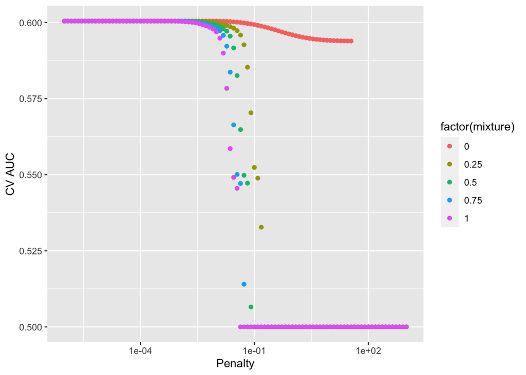

```r
logit_fit |>
  # aggregate metrics from K folds
  collect_metrics() |>
  print(width = Inf) |>
  filter(.metric == "roc_auc") |>
  ggplot(mapping = aes(x = penalty, y = mean, color = factor(mixture))) +
  geom_point() +
  labs(x = "Penalty", y = "CV AUC") +
  scale_x_log10()
```

Show the top 5 models.

```r
logit_fit |>
  show_best("roc_auc")
```

```
# A tibble: 5 × 8
     penalty mixture .metric .estimator  mean     n std_err .config
       <dbl>   <dbl> <chr>   <chr>      <dbl> <int>   <dbl> <chr>
1 0.000001         0 roc_auc binary     0.600     5 0.00331 Preprocessor1_Model…
2 0.00000123       0 roc_auc binary     0.600     5 0.00331 Preprocessor1_Model…
3 0.00000152       0 roc_auc binary     0.600     5 0.00331 Preprocessor1_Model…
4 0.00000187       0 roc_auc binary     0.600     5 0.00331 Preprocessor1_Model…
5 0.00000231       0 roc_auc binary     0.600     5 0.00331 Preprocessor1_Model…
```

Select the best model.

```r
best_logit <- logit_fit |>
  select_best("roc_auc")
best_logit
```

```
# A tibble: 1 × 3
   penalty mixture .config
     <dbl>   <dbl> <chr>
1 0.000001       0 Preprocessor1_Model001
```

**Finalize the model:**

Final workflow.

```r
final_wf_logit <- logit_wf |>
  finalize_workflow(best_logit)
final_wf_logit
```

```
══ Workflow ════════════════════════════════════════════════════════════════════
Preprocessor: Recipe
Model: logistic_reg()

── Preprocessor ────────────────────────────────────────────────────────────────
17 Recipe Steps

• step_impute_mean()
• step_impute_mean()
• step_impute_mean()
• step_impute_mean()
• step_impute_mean()
• step_impute_mean()
• step_impute_mean()
• step_impute_mean()
• step_impute_mean()
• step_impute_mean()
• ...
• and 7 more steps.

── Model ───────────────────────────────────────────────────────────────────────
Logistic Regression Model Specification (classification)

Main Arguments:
  penalty = 1e-06
  mixture = 0

Engine-Specific Arguments:
  standardize = FALSE

Computational engine: glmnet
```

Fit the whole training set, then predict the test cases.

```r
final_fit_logit <-
  final_wf_logit |>
  last_fit(data_split)
final_fit_logit
```

```
# Resampling results
# Manual resampling
# A tibble: 1 × 6
  splits                id             .metrics .notes   .predictions .workflow
  <list>                <chr>          <list>   <list>   <list>       <list>
1 <split [36590/36591]> train/test sp… <tibble> <tibble> <tibble>     <workflow>
```

Test metrics.

```r
final_fit_logit |>
  collect_metrics()
```

```
# A tibble: 2 × 4
  .metric  .estimator .estimate .config
  <chr>    <chr>          <dbl> <chr>
1 accuracy binary         0.573 Preprocessor1_Model1
2 roc_auc  binary         0.597 Preprocessor1_Model1
```

Accuracy of test dataset:

```r
accuracy_logit <- final_fit_logit |>
  collect_metrics() |>
  filter(.metric == "accuracy") |>
  pull(.estimate)
accuracy_logit
```

```
[1] 0.5728731
```

ROC AUC of test dataset:

```r
roc_auc_logit <- final_fit_logit |>
  collect_metrics() |>
  filter(.metric == "roc_auc") |>
  pull(.estimate)
roc_auc_logit
```

```
[1] 0.5969317
```

**Random forest:**

**Recipe:**

```r
rf_recipe <-
  recipe(
    los_long ~ .,
    data = mimic_other
  ) |>
  # # create traditional dummy variables (not necessary for random forest in R)
  # step_dummy(all_nominal()) |>

  # mean imputation for numeric variables
  step_impute_mean(bicarbonate) |>
  step_impute_mean(chloride) |>
  step_impute_mean(creatinine) |>
  step_impute_mean(glucose) |>
  step_impute_mean(potassium) |>
  step_impute_mean(sodium) |>
  step_impute_mean(hematocrit) |>
  step_impute_mean(wbc) |>
  step_impute_mean(heart_rate) |>
  step_impute_mean(non_invasive_blood_pressure_systolic) |>
  step_impute_mean(temperature_fahrenheit) |>
  step_impute_mean(non_invasive_blood_pressure_diastolic) |>
  step_impute_mean(respiratory_rate) |>

  # mode imputation for categorical variables
  step_impute_mode(marital_status) |>

  # zero-variance filter
  step_zv(all_numeric_predictors()) |>
  # # center and scale numeric data (not necessary for random forest)
  # step_normalize(all_numeric_predictors()) |>

  # estimate the means and standard deviations
  prep(training = mimic_other, retain = TRUE) |>
  print()
```

```
── Recipe ──────────────────────────────────────────────────────────────────────
```

```
── Inputs
```

```
Number of variables by role
```

```
outcome:    1
predictor: 18
```

```
── Training information
```

```
Training data contained 36590 data points and 7229 incomplete rows.
```

```
── Operations
```

```
• Mean imputation for: bicarbonate | Trained
```

```
• Mean imputation for: chloride | Trained
```

```
• Mean imputation for: creatinine | Trained
```

```
• Mean imputation for: glucose | Trained
```

```
• Mean imputation for: potassium | Trained
```

```
• Mean imputation for: sodium | Trained
```

```
• Mean imputation for: hematocrit | Trained
```

```
• Mean imputation for: wbc | Trained
```

```
• Mean imputation for: heart_rate | Trained
```

```
• Mean imputation for: non_invasive_blood_pressure_systolic | Trained
```

```
• Mean imputation for: temperature_fahrenheit | Trained
```

```
• Mean imputation for: non_invasive_blood_pressure_diastolic | Trained
```

```
• Mean imputation for: respiratory_rate | Trained
```

```
• Mode imputation for: marital_status | Trained
```

```
• Zero variance filter removed: <none> | Trained
```

**Model:**

```r
rf_mod <-
  rand_forest(
    mode = "classification",
    # Number of predictors randomly sampled in each split
    mtry = tune(),
    # Number of trees in ensemble
    trees = tune()
  ) |>
  set_engine("ranger", importance = "impurity")
rf_mod
```

```
Random Forest Model Specification (classification)

Main Arguments:
  mtry = tune()
  trees = tune()

Engine-Specific Arguments:
  importance = impurity

Computational engine: ranger
```

**Workflow:**

```r
rf_wf <- workflow() |>
  add_recipe(rf_recipe) |>
  add_model(rf_mod)
rf_wf
```

```
══ Workflow ════════════════════════════════════════════════════════════════════
Preprocessor: Recipe
Model: rand_forest()

── Preprocessor ────────────────────────────────────────────────────────────────
15 Recipe Steps

• step_impute_mean()
• step_impute_mean()
• step_impute_mean()
• step_impute_mean()
• step_impute_mean()
• step_impute_mean()
• step_impute_mean()
• step_impute_mean()
• step_impute_mean()
• step_impute_mean()
• ...
• and 5 more steps.

── Model ───────────────────────────────────────────────────────────────────────
Random Forest Model Specification (classification)

Main Arguments:
  mtry = tune()
  trees = tune()

Engine-Specific Arguments:
  importance = impurity

Computational engine: ranger
```

**Tuning grid:**

```r
rf_grid <- grid_regular(
  trees(range = c(100L, 500L)),
  mtry(range = c(1L, 5L)),
  levels = c(5, 5)
  )
rf_grid
```

```
# A tibble: 25 × 2
   trees  mtry
   <int> <int>
 1   100     1
 2   200     1
 3   300     1
 4   400     1
 5   500     1
 6   100     2
 7   200     2
 8   300     2
 9   400     2
10   500     2
# ℹ 15 more rows
```

**Cross-validation:**

```r
set.seed(203)

folds <- vfold_cv(mimic_other, v = 5)
folds
```

```
#  5-fold cross-validation
# A tibble: 5 × 2
  splits               id
  <list>               <chr>
1 <split [29272/7318]> Fold1
2 <split [29272/7318]> Fold2
3 <split [29272/7318]> Fold3
4 <split [29272/7318]> Fold4
5 <split [29272/7318]> Fold5
```

Fit cross-validation.

```r
rf_fit <- rf_wf |>
  tune_grid(
    resamples = folds,
    grid = rf_grid,
    #metrics = metric_set(roc_auc, accuracy),
    control = control_stack_grid()
    )
rf_fit
```

```
# Tuning results
# 5-fold cross-validation
# A tibble: 5 × 5
  splits               id    .metrics          .notes           .predictions
  <list>               <chr> <list>            <list>           <list>
1 <split [29272/7318]> Fold1 <tibble [50 × 6]> <tibble [0 × 3]> <tibble>
2 <split [29272/7318]> Fold2 <tibble [50 × 6]> <tibble [0 × 3]> <tibble>
3 <split [29272/7318]> Fold3 <tibble [50 × 6]> <tibble [0 × 3]> <tibble>
4 <split [29272/7318]> Fold4 <tibble [50 × 6]> <tibble [0 × 3]> <tibble>
5 <split [29272/7318]> Fold5 <tibble [50 × 6]> <tibble [0 × 3]> <tibble>
```

Visualize CV results:

```
# A tibble: 50 × 8
    mtry trees .metric  .estimator  mean     n std_err .config
   <int> <int> <chr>    <chr>      <dbl> <int>   <dbl> <chr>
 1     1   100 accuracy binary     0.586     5 0.00339 Preprocessor1_Model01
 2     1   100 roc_auc  binary     0.623     5 0.00296 Preprocessor1_Model01
 3     1   200 accuracy binary     0.591     5 0.00212 Preprocessor1_Model02
 4     1   200 roc_auc  binary     0.631     5 0.00250 Preprocessor1_Model02
 5     1   300 accuracy binary     0.593     5 0.00296 Preprocessor1_Model03
 6     1   300 roc_auc  binary     0.633     5 0.00216 Preprocessor1_Model03
 7     1   400 accuracy binary     0.593     5 0.00349 Preprocessor1_Model04
 8     1   400 roc_auc  binary     0.632     5 0.00282 Preprocessor1_Model04
 9     1   500 accuracy binary     0.594     5 0.00405 Preprocessor1_Model05
10     1   500 roc_auc  binary     0.634     5 0.00296 Preprocessor1_Model05
# ℹ 40 more rows
```

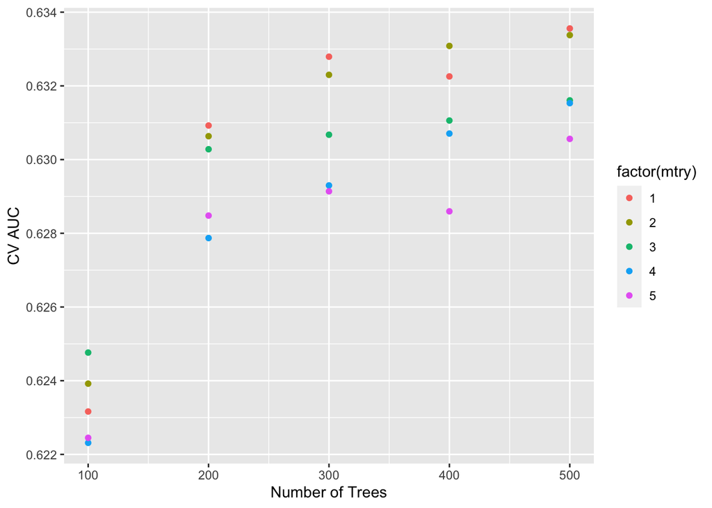

```r
rf_fit |>
  collect_metrics() |>
  print(width = Inf) |>
  filter(.metric == "roc_auc") |>
  ggplot(mapping = aes(x = trees, y = mean, color = factor(mtry))) +
  geom_point() +
  # geom_line() +
  labs(x = "Number of Trees", y = "CV AUC")
```

Show the top 5 models.

```r
rf_fit |>
  show_best("roc_auc")
```

```
# A tibble: 5 × 8
   mtry trees .metric .estimator  mean     n std_err .config
  <int> <int> <chr>   <chr>      <dbl> <int>   <dbl> <chr>
1     1   500 roc_auc binary     0.634     5 0.00296 Preprocessor1_Model05
2     2   500 roc_auc binary     0.633     5 0.00257 Preprocessor1_Model10
3     2   400 roc_auc binary     0.633     5 0.00279 Preprocessor1_Model09
4     1   300 roc_auc binary     0.633     5 0.00216 Preprocessor1_Model03
5     2   300 roc_auc binary     0.632     5 0.00280 Preprocessor1_Model08
```

Select the best model.

```r
best_rf <- rf_fit |>
  select_best("roc_auc")
best_rf
```

```
# A tibble: 1 × 3
   mtry trees .config
  <int> <int> <chr>
1     1   500 Preprocessor1_Model05
```

**Finalize the model:**

Final workflow.

```r
final_wf_rf <- rf_wf |>
  finalize_workflow(best_rf)
final_wf_rf
```

```
══ Workflow ════════════════════════════════════════════════════════════════════
Preprocessor: Recipe
Model: rand_forest()

── Preprocessor ────────────────────────────────────────────────────────────────
15 Recipe Steps

• step_impute_mean()
• step_impute_mean()
• step_impute_mean()
• step_impute_mean()
• step_impute_mean()
• step_impute_mean()
• step_impute_mean()
• step_impute_mean()
• step_impute_mean()
• step_impute_mean()
• ...
• and 5 more steps.

── Model ───────────────────────────────────────────────────────────────────────
Random Forest Model Specification (classification)

Main Arguments:
  mtry = 1
  trees = 500

Engine-Specific Arguments:
  importance = impurity

Computational engine: ranger
```

Fit the whole training set, then predict the test cases.

```r
final_fit_rf <-
  final_wf_rf |>
  last_fit(data_split)
final_fit_rf
```

```
# Resampling results
# Manual resampling
# A tibble: 1 × 6
  splits                id             .metrics .notes   .predictions .workflow
  <list>                <chr>          <list>   <list>   <list>       <list>
1 <split [36590/36591]> train/test sp… <tibble> <tibble> <tibble>     <workflow>
```

Importance of features:

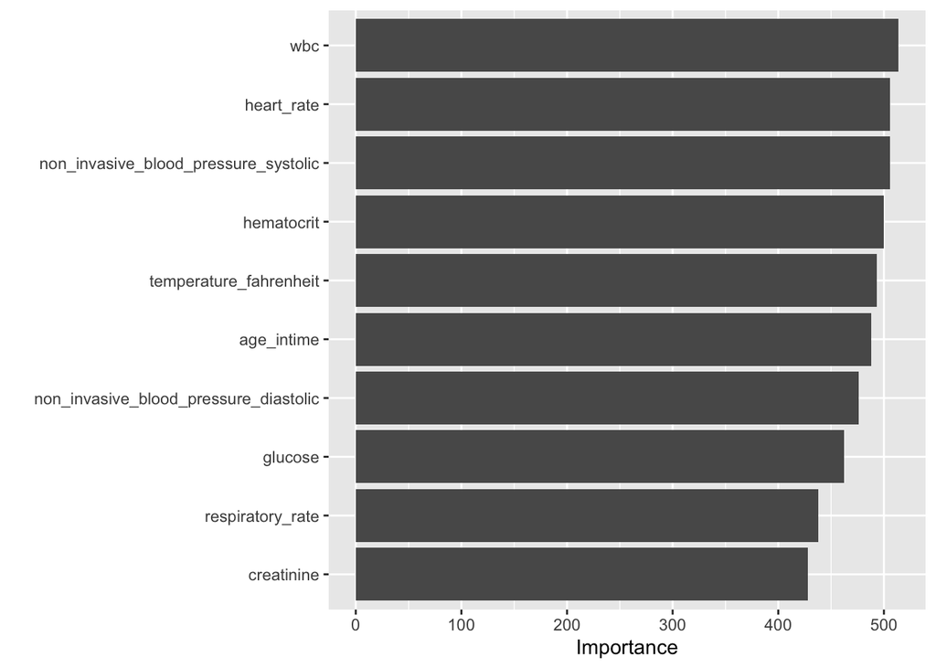

```r
final_fit_rf %>%
  extract_fit_parsnip() %>%
  vip()
```

Test metrics.

```r
final_fit_rf |>
  collect_metrics()
```

```
# A tibble: 2 × 4
  .metric  .estimator .estimate .config
  <chr>    <chr>          <dbl> <chr>
1 accuracy binary         0.598 Preprocessor1_Model1
2 roc_auc  binary         0.634 Preprocessor1_Model1
```

Accuracy of test dataset:

```r
accuracy_rf <- final_fit_rf |>
  collect_metrics() |>
  filter(.metric == "accuracy") |>
  pull(.estimate)
accuracy_rf
```

```
[1] 0.5978246
```

ROC AUC of test dataset:

```r
roc_auc_rf <- final_fit_rf |>
  collect_metrics() |>
  filter(.metric == "roc_auc") |>
  pull(.estimate)
roc_auc_rf
```

```
[1] 0.6341778
```

**Boosting:**

**Recipe:**

```r
gb_recipe <-
  recipe(
    los_long ~ .,
    data = mimic_other
  ) |>

  # mean imputation for numeric variables
  step_impute_mean(bicarbonate) |>
  step_impute_mean(chloride) |>
  step_impute_mean(creatinine) |>
  step_impute_mean(glucose) |>
  step_impute_mean(potassium) |>
  step_impute_mean(sodium) |>
  step_impute_mean(hematocrit) |>
  step_impute_mean(wbc) |>
  step_impute_mean(heart_rate) |>
  step_impute_mean(non_invasive_blood_pressure_systolic) |>
  step_impute_mean(temperature_fahrenheit) |>
  step_impute_mean(non_invasive_blood_pressure_diastolic) |>
  step_impute_mean(respiratory_rate) |>

  # mode imputation for categorical variables
  step_impute_mode(marital_status) |>

  # create traditional dummy variables (necessary for xgboost)
  step_dummy(all_nominal_predictors()) |>

  # zero-variance filter
  step_zv(all_numeric_predictors()) |>

  # estimate the means and standard deviations
  prep(training = mimic_other, retain = TRUE) |>

  print()
```

```
── Recipe ──────────────────────────────────────────────────────────────────────
```

```
── Inputs
```

```
Number of variables by role
```

```
outcome:    1
predictor: 18
```

```
── Training information
```

```
Training data contained 36590 data points and 7229 incomplete rows.
```

```
── Operations
```

```
• Mean imputation for: bicarbonate | Trained
```

```
• Mean imputation for: chloride | Trained
```

```
• Mean imputation for: creatinine | Trained
```

```
• Mean imputation for: glucose | Trained
```

```
• Mean imputation for: potassium | Trained
```

```
• Mean imputation for: sodium | Trained
```

```
• Mean imputation for: hematocrit | Trained
```

```
• Mean imputation for: wbc | Trained
```

```
• Mean imputation for: heart_rate | Trained
```

```
• Mean imputation for: non_invasive_blood_pressure_systolic | Trained
```

```
• Mean imputation for: temperature_fahrenheit | Trained
```

```
• Mean imputation for: non_invasive_blood_pressure_diastolic | Trained
```

```
• Mean imputation for: respiratory_rate | Trained
```

```
• Mode imputation for: marital_status | Trained
```

```
• Dummy variables from: gender, marital_status, race, ... | Trained
```

```
• Zero variance filter removed: <none> | Trained
```

**Model:**

```r
gb_mod <-
  boost_tree(
    mode = "classification",
    trees = 1000,
    tree_depth = tune(),
    learn_rate = tune()
  ) |>
  set_engine("xgboost")
gb_mod
```

```
Boosted Tree Model Specification (classification)

Main Arguments:
  trees = 1000
  tree_depth = tune()
  learn_rate = tune()

Computational engine: xgboost
```

**Workflow:**

```r
gb_wf <- workflow() |>
  add_recipe(gb_recipe) |>
  add_model(gb_mod)
gb_wf
```

```
══ Workflow ════════════════════════════════════════════════════════════════════
Preprocessor: Recipe
Model: boost_tree()

── Preprocessor ────────────────────────────────────────────────────────────────
16 Recipe Steps

• step_impute_mean()
• step_impute_mean()
• step_impute_mean()
• step_impute_mean()
• step_impute_mean()
• step_impute_mean()
• step_impute_mean()
• step_impute_mean()
• step_impute_mean()
• step_impute_mean()
• ...
• and 6 more steps.

── Model ───────────────────────────────────────────────────────────────────────
Boosted Tree Model Specification (classification)

Main Arguments:
  trees = 1000
  tree_depth = tune()
  learn_rate = tune()

Computational engine: xgboost
```

**Tuning grid:**

```r
gb_grid <- grid_regular(
  tree_depth(range = c(1L, 3L)),
  learn_rate(range = c(-5, 2), trans = log10_trans()),
  levels = c(3, 10)
  )
gb_grid
```

```
# A tibble: 30 × 2
   tree_depth learn_rate
        <int>      <dbl>
 1          1  0.00001
 2          2  0.00001
 3          3  0.00001
 4          1  0.0000599
 5          2  0.0000599
 6          3  0.0000599
 7          1  0.000359
 8          2  0.000359
 9          3  0.000359
10          1  0.00215
# ℹ 20 more rows
```

**Cross-validation:**

```r
set.seed(203)

folds <- vfold_cv(mimic_other, v = 5)
folds
```

```
#  5-fold cross-validation
# A tibble: 5 × 2
  splits               id
  <list>               <chr>
1 <split [29272/7318]> Fold1
2 <split [29272/7318]> Fold2
3 <split [29272/7318]> Fold3
4 <split [29272/7318]> Fold4
5 <split [29272/7318]> Fold5
```

Fit cross-validation.

```r
gb_fit <- gb_wf |>
  tune_grid(
    resamples = folds,
    grid = gb_grid,
    metrics = metric_set(roc_auc, accuracy),
    control = control_stack_grid()
    )
```

```
ℹ The workflow being saved contains a recipe, which is 7.42 Mb in ℹ memory. If
this was not intentional, please set the control setting ℹ `save_workflow =
FALSE`.
```

```r
gb_fit
```

```
# Tuning results
# 5-fold cross-validation
# A tibble: 5 × 5
  splits               id    .metrics          .notes           .predictions
  <list>               <chr> <list>            <list>           <list>
1 <split [29272/7318]> Fold1 <tibble [60 × 6]> <tibble [0 × 3]> <tibble>
2 <split [29272/7318]> Fold2 <tibble [60 × 6]> <tibble [0 × 3]> <tibble>
3 <split [29272/7318]> Fold3 <tibble [60 × 6]> <tibble [0 × 3]> <tibble>
4 <split [29272/7318]> Fold4 <tibble [60 × 6]> <tibble [0 × 3]> <tibble>
5 <split [29272/7318]> Fold5 <tibble [60 × 6]> <tibble [0 × 3]> <tibble>
```

Visualize CV results:

```
# A tibble: 60 × 8
   tree_depth learn_rate .metric  .estimator  mean     n std_err
        <int>      <dbl> <chr>    <chr>      <dbl> <int>   <dbl>
 1          1  0.00001   accuracy binary     0.539     5 0.00326
 2          1  0.00001   roc_auc  binary     0.538     5 0.00237
 3          2  0.00001   accuracy binary     0.539     5 0.00367
 4          2  0.00001   roc_auc  binary     0.554     5 0.00115
 5          3  0.00001   accuracy binary     0.550     5 0.00370
 6          3  0.00001   roc_auc  binary     0.565     5 0.00116
 7          1  0.0000599 accuracy binary     0.540     5 0.00245
 8          1  0.0000599 roc_auc  binary     0.541     5 0.00338
 9          2  0.0000599 accuracy binary     0.543     5 0.00247
10          2  0.0000599 roc_auc  binary     0.560     5 0.00263
   .config
   <chr>
 1 Preprocessor1_Model01
 2 Preprocessor1_Model01
 3 Preprocessor1_Model02
 4 Preprocessor1_Model02
 5 Preprocessor1_Model03
 6 Preprocessor1_Model03
 7 Preprocessor1_Model04
 8 Preprocessor1_Model04
 9 Preprocessor1_Model05
10 Preprocessor1_Model05
# ℹ 50 more rows
```

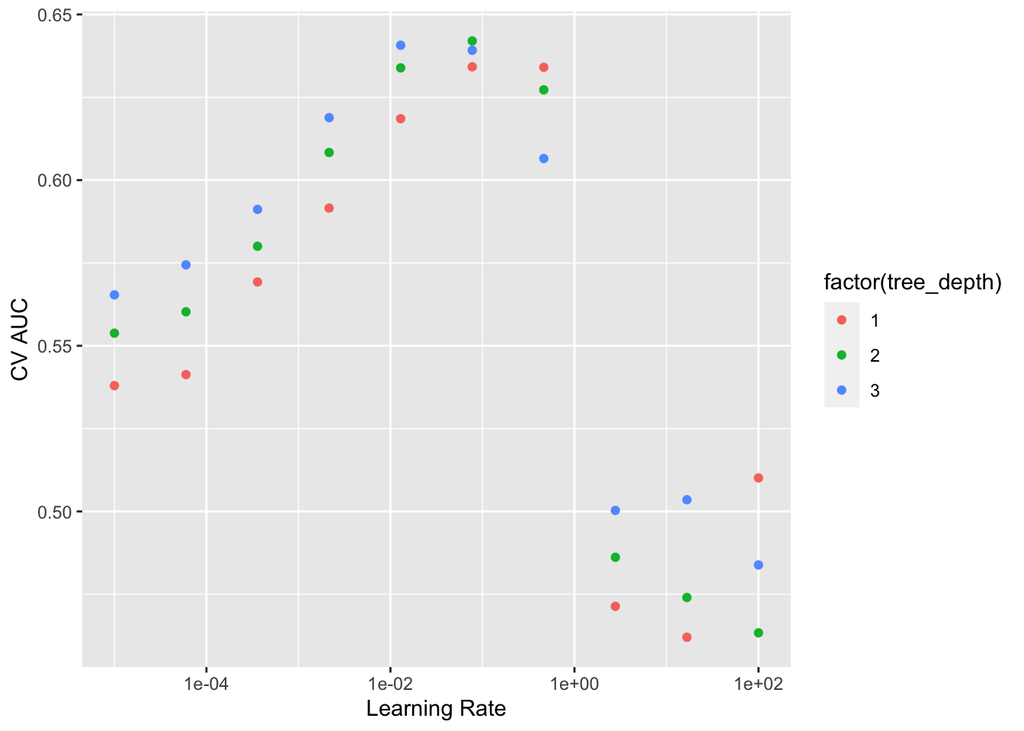

```r
gb_fit |>
  collect_metrics() |>
  print(width = Inf) |>
  filter(.metric == "roc_auc") |>
  ggplot(mapping = aes(x = learn_rate, y = mean, color = factor(tree_depth))) +
  geom_point() +
  labs(x = "Learning Rate", y = "CV AUC") +
  scale_x_log10()
```

Show the top 5 models.

```r
gb_fit |>
  show_best("roc_auc")
```

```
# A tibble: 5 × 8
  tree_depth learn_rate .metric .estimator  mean     n std_err .config
       <int>      <dbl> <chr>   <chr>      <dbl> <int>   <dbl> <chr>
1          2     0.0774 roc_auc binary     0.642     5 0.00299 Preprocessor1_Mo…
2          3     0.0129 roc_auc binary     0.641     5 0.00332 Preprocessor1_Mo…
3          3     0.0774 roc_auc binary     0.639     5 0.00240 Preprocessor1_Mo…
4          1     0.0774 roc_auc binary     0.634     5 0.00315 Preprocessor1_Mo…
5          1     0.464  roc_auc binary     0.634     5 0.00316 Preprocessor1_Mo…
```

Select the best model.

```r
best_gb <- gb_fit |>
  select_best("roc_auc")
best_gb
```

```
# A tibble: 1 × 3
  tree_depth learn_rate .config
       <int>      <dbl> <chr>
1          2     0.0774 Preprocessor1_Model17
```

**Finalize the model:**

Final workflow.

```r
final_wf_gb <- gb_wf |>
  finalize_workflow(best_gb)
final_wf_gb
```

```
══ Workflow ════════════════════════════════════════════════════════════════════
Preprocessor: Recipe
Model: boost_tree()

── Preprocessor ────────────────────────────────────────────────────────────────
16 Recipe Steps

• step_impute_mean()
• step_impute_mean()
• step_impute_mean()
• step_impute_mean()
• step_impute_mean()
• step_impute_mean()
• step_impute_mean()
• step_impute_mean()
• step_impute_mean()
• step_impute_mean()
• ...
• and 6 more steps.

── Model ───────────────────────────────────────────────────────────────────────
Boosted Tree Model Specification (classification)

Main Arguments:
  trees = 1000
  tree_depth = 2
  learn_rate = 0.0774263682681127

Computational engine: xgboost
```

Fit the whole training set, then predict the test cases.

```r
final_fit_gb <-
  final_wf_gb |>
  last_fit(data_split)
final_fit_gb
```

```
# Resampling results
# Manual resampling
# A tibble: 1 × 6
  splits                id             .metrics .notes   .predictions .workflow
  <list>                <chr>          <list>   <list>   <list>       <list>
1 <split [36590/36591]> train/test sp… <tibble> <tibble> <tibble>     <workflow>
```

Importance of features:

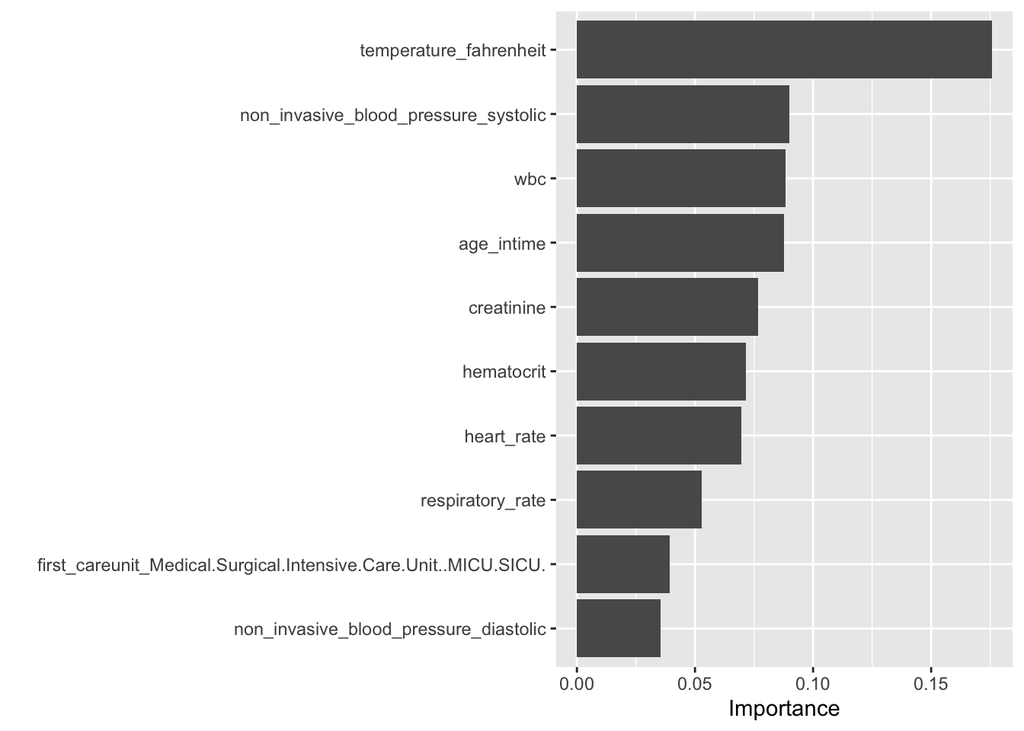

```r
final_fit_gb %>%
  extract_fit_parsnip() %>%
  vip()
```

Test metrics.

```r
final_fit_gb |>
  collect_metrics()
```

```
# A tibble: 2 × 4
  .metric  .estimator .estimate .config
  <chr>    <chr>          <dbl> <chr>
1 accuracy binary         0.600 Preprocessor1_Model1
2 roc_auc  binary         0.642 Preprocessor1_Model1
```

Accuracy of test dataset:

```r
accuracy_gb <- final_fit_gb |>
  collect_metrics() |>
  filter(.metric == "accuracy") |>
  pull(.estimate)
accuracy_gb
```

```
[1] 0.6004209
```

ROC AUC of test dataset:

```r
roc_auc_gb <- final_fit_gb |>
  collect_metrics() |>
  filter(.metric == "roc_auc") |>
  pull(.estimate)
roc_auc_gb
```

```
[1] 0.6417356
```

**Model stacking:**

Build the stacked ensemble.

```r
mimic_model_st <-
  # initialize the stack
  stacks() |>
  # add candidate members
  # add_candidates(logit_fit) |>
  add_candidates(rf_fit) |>
  add_candidates(gb_fit) |>
  # determine how to combine their predictions
  blend_predictions(
    penalty = 10^(-6:2),
    metrics = c("roc_auc")
    ) |>
  # fit the candidates with nonzero stacking coefficients
  fit_members()
```

```r
mimic_model_st
```

```
── A stacked ensemble model ─────────────────────────────────────


Out of 55 possible candidate members, the ensemble retained 21.

Penalty: 0.001.

Mixture: 1.


The 10 highest weighted member classes are:
```

```
# A tibble: 10 × 3
   member                type        weight
   <chr>                 <chr>        <dbl>
 1 .pred_yes_gb_fit_1_17 boost_tree   1.54
 2 .pred_yes_rf_fit_1_12 rand_forest  0.609
 3 .pred_yes_rf_fit_1_02 rand_forest  0.491
 4 .pred_yes_gb_fit_1_18 boost_tree   0.461
 5 .pred_yes_gb_fit_1_15 boost_tree   0.404
 6 .pred_yes_rf_fit_1_08 rand_forest  0.353
 7 .pred_yes_rf_fit_1_22 rand_forest  0.324
 8 .pred_yes_rf_fit_1_03 rand_forest  0.275
 9 .pred_yes_gb_fit_1_20 boost_tree   0.247
10 .pred_yes_gb_fit_1_19 boost_tree   0.222
```

Plot the result.

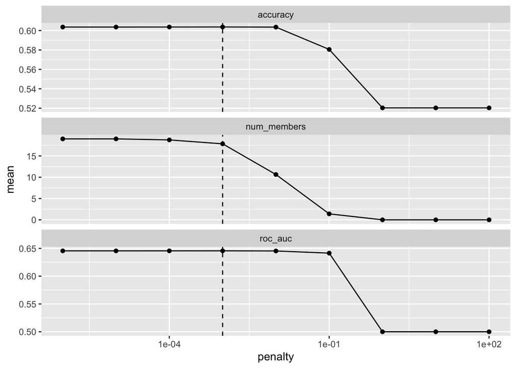

```r
autoplot(mimic_model_st)
```

To show the relationship more directly:

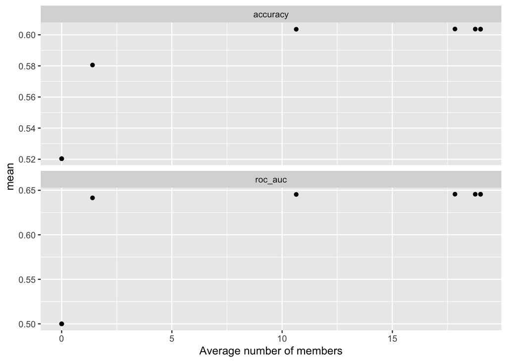

```r
autoplot(mimic_model_st, type = "members")
```

To see the top results:

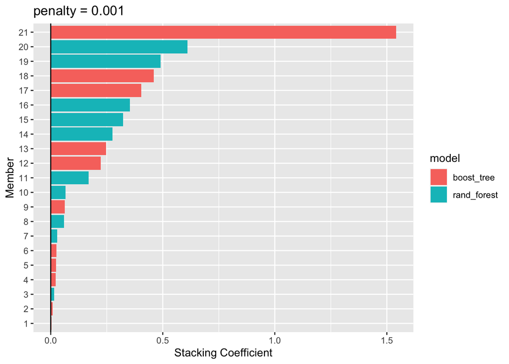

```r
autoplot(mimic_model_st, type = "weights")
```

To identify which model configurations were assigned what stacking coefficients, we can make use of the collect_parameters() function:

```r
collect_parameters(mimic_model_st, "rf_fit")
```

```
# A tibble: 25 × 5
   member       mtry trees terms                   coef
   <chr>       <int> <int> <chr>                  <dbl>
 1 rf_fit_1_01     1   100 .pred_yes_rf_fit_1_01 0
 2 rf_fit_1_02     1   200 .pred_yes_rf_fit_1_02 0.491
 3 rf_fit_1_03     1   300 .pred_yes_rf_fit_1_03 0.275
 4 rf_fit_1_04     1   400 .pred_yes_rf_fit_1_04 0
 5 rf_fit_1_05     1   500 .pred_yes_rf_fit_1_05 0.0148
 6 rf_fit_1_06     2   100 .pred_yes_rf_fit_1_06 0
 7 rf_fit_1_07     2   200 .pred_yes_rf_fit_1_07 0.170
 8 rf_fit_1_08     2   300 .pred_yes_rf_fit_1_08 0.353
 9 rf_fit_1_09     2   400 .pred_yes_rf_fit_1_09 0.0281
10 rf_fit_1_10     2   500 .pred_yes_rf_fit_1_10 0.0657
# ℹ 15 more rows
```

```r
collect_parameters(mimic_model_st, "gb_fit")
```

```
# A tibble: 30 × 5
   member      tree_depth learn_rate terms                  coef
   <chr>            <int>      <dbl> <chr>                 <dbl>
 1 gb_fit_1_01          1  0.00001   .pred_yes_gb_fit_1_01     0
 2 gb_fit_1_02          2  0.00001   .pred_yes_gb_fit_1_02     0
 3 gb_fit_1_03          3  0.00001   .pred_yes_gb_fit_1_03     0
 4 gb_fit_1_04          1  0.0000599 .pred_yes_gb_fit_1_04     0
 5 gb_fit_1_05          2  0.0000599 .pred_yes_gb_fit_1_05     0
 6 gb_fit_1_06          3  0.0000599 .pred_yes_gb_fit_1_06     0
 7 gb_fit_1_07          1  0.000359  .pred_yes_gb_fit_1_07     0
 8 gb_fit_1_08          2  0.000359  .pred_yes_gb_fit_1_08     0
 9 gb_fit_1_09          3  0.000359  .pred_yes_gb_fit_1_09     0
10 gb_fit_1_10          1  0.00215   .pred_yes_gb_fit_1_10     0
# ℹ 20 more rows
```

**Finalize classification:**

```r
mimic_pred <- mimic_test %>%
  bind_cols(predict(mimic_model_st, ., type = "prob")) %>%
  print(width = Inf)
```

```
# A tibble: 36,591 × 21
   los_long gender age_intime marital_status race
   <fct>    <fct>       <int> <fct>          <fct>
 1 no       F              52 WIDOWED        WHITE
 2 no       F              55 MARRIED        WHITE
 3 no       F              55 MARRIED        WHITE
 4 no       F              46 MARRIED        WHITE
 5 no       F              57 SINGLE         OTHER
 6 yes      F              81 MARRIED        WHITE
 7 yes      F              81 WIDOWED        WHITE
 8 yes      F              81 WIDOWED        WHITE
 9 yes      M              90 WIDOWED        WHITE
10 yes      M              81 MARRIED        OTHER
   first_careunit                                   bicarbonate chloride
   <fct>                                                  <dbl>    <dbl>
```

[output cut: 47 more lines]

```r
mimic_pred_st <- mimic_test %>%
  bind_cols(predict(mimic_model_st, mimic_test)) %>%
  print(width = Inf)
```

```
# A tibble: 36,591 × 20
   los_long gender age_intime marital_status race
   <fct>    <fct>       <int> <fct>          <fct>
 1 no       F              52 WIDOWED        WHITE
 2 no       F              55 MARRIED        WHITE
 3 no       F              55 MARRIED        WHITE
 4 no       F              46 MARRIED        WHITE
 5 no       F              57 SINGLE         OTHER
 6 yes      F              81 MARRIED        WHITE
 7 yes      F              81 WIDOWED        WHITE
 8 yes      F              81 WIDOWED        WHITE
 9 yes      M              90 WIDOWED        WHITE
10 yes      M              81 MARRIED        OTHER
   first_careunit                                   bicarbonate chloride
   <fct>                                                  <dbl>    <dbl>
```

[output cut: 47 more lines]

```r
accuracy <- mimic_pred_st %>%
  accuracy(truth = los_long, estimate = .pred_class)
accuracy
```

```
# A tibble: 1 × 3
  .metric  .estimator .estimate
  <chr>    <chr>          <dbl>
1 accuracy binary         0.605
```

Computing the ROC AUC for the model:

```r
roc_auc_st <- yardstick::roc_auc(
  mimic_pred,
  truth = los_long,
  contains(".pred_No")
  )
roc_auc_st
```

```
# A tibble: 1 × 3
  .metric .estimator .estimate
  <chr>   <chr>          <dbl>
1 roc_auc binary         0.648
```

Accuracy of test dataset:

```r
accuracy_st <- accuracy |>
  filter(.metric == "accuracy") |>
  pull(.estimate)
accuracy_st
```

```
[1] 0.6045749
```

ROC AUC of test dataset:

```r
roc_auc_st <- roc_auc_st |>
  filter(.metric == "roc_auc") |>
  pull(.estimate)
roc_auc_st
```

```
[1] 0.6476766
```

4. Compare model classification performance on the test set. Report both the area under ROC curve and accuracy for each machine learning algorithm and the model stacking. Interpret the results. What are the most important features in predicting long ICU stays? How do the models compare in terms of performance and interpretability?

```r
# Create a tibble with the variables
model_metrics <- tibble(
  Model = c("Logistic Regression", "Random Forest",
            "Boosting", "Model Stacking"),
  Accuracy = c(accuracy_logit, accuracy_rf, accuracy_gb, accuracy_st),
  ROC_AUC = c(roc_auc_logit, roc_auc_rf, roc_auc_gb, roc_auc_st)
)

# Print the tibble
print(model_metrics)
```

```
# A tibble: 4 × 3
  Model               Accuracy ROC_AUC
  <chr>                  <dbl>   <dbl>
1 Logistic Regression    0.573   0.597
2 Random Forest          0.598   0.634
3 Boosting               0.600   0.642
4 Model Stacking         0.605   0.648
```

**Accuracy:**

This metric represents the proportion of correctly classified instances by the model. Among the individual algorithms, Boosting and Random Forest perform slightly better than Logistic Regression. Model Stacking, which combines the predictions of multiple models, achieves the highest accuracy among all models.

**ROC AUC:**

ROC AUC (Receiver Operating Characteristic Area Under Curve) is a metric that evaluates the model’s ability to discriminate between positive and negative classes. Similar to accuracy, Model Stacking has the highest ROC AUC score, indicating better overall performance in distinguishing between classes.

**Feature Importance:**

Based on Random Forest model, the most important features in predicting long ICU is White Blood Cell Count. Based on Boosting model, the most important features in predicting long ICU is Temperature Fahrenheit.

**Performance and Interpretability:**

In terms of performance, Model Stacking generally outperforms individual algorithms in both accuracy and ROC AUC. However, Model Stacking might sacrifice some interpretability as it combines predictions from multiple models, making it harder to understand the contribution of individual features. Among individual algorithms, Random Forest and Boosting tend to offer good performance while maintaining some level of interpretability, especially in terms of feature importance. Logistic Regression is often highly interpretable due to its linear nature and easy interpretation of coefficients, but it may not capture complex relationships as effectively as tree-based models like Random Forest and Boosting.